fossil

# Subgroup power, dug back up.

Hayward, Kent, Vijan and Hofer simulated thousands of clinical trials in 2006 and released no code. In November 2026 we rebuilt the simulation from the paper and reran every setting. Of 19 results we tried, 8 agree, 9 partly agree and 2 differ. The main claim came back.

See every resultSee the tables

## Fig. 1A

Fig. 1A. Net relative risk reduction against the 5-year control event rate, when treatment halves the risk but adds 3 complications per 1,000 treated per year.

Agrees

Published

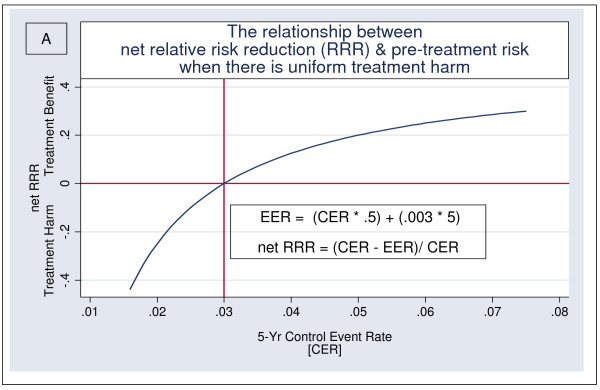

Our run

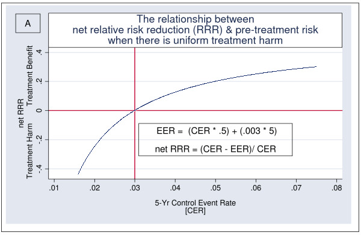

**Fig. 1A, net RRR against pre-treatment risk**

100.0% of the curve within 2 px both ways (pass 95%, best control 70.3%), Agrees

## Fig. 1B

Partly agrees

Published

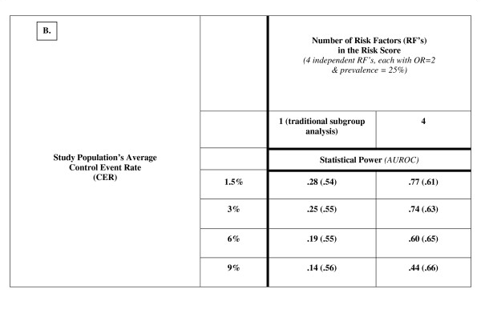

Our run

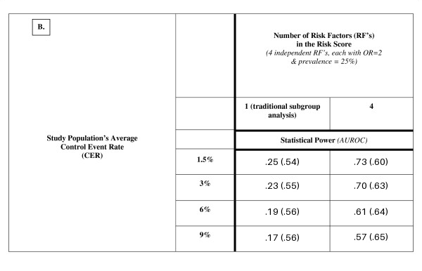

**Fig. 1B, power and AUROC of one RF and of a 4-RF score at four average CERs**

9 of 16 values within tolerance, Partly agrees

21 of 41 printed powers come back within Monte Carlo error. Of the 20 that do not, 16 are higher than the paper's and 4 lower, by up to 13 points; the higher ones are where the heterogeneity in net benefit is large (ORs of 3, Table 4's weighted scores, Fig. 1B at 9%). Our two runs agree with each other in 41 of 41 powers, so the gap is not our Monte Carlo error. None of the tested readings of the paper closes it; a finite simulated population, which the paper's 'drawing observations with replacement from a population' allows, would move each power by chance (SD 0.05 to 0.08 with 100,000 people, 0.16 to 0.25 with 8,800), but its size is not given.

## The tables

Each power is compared at half a printed unit plus three combined Monte Carlo standard errors (the paper ran 2,000 trials, we ran 20,000). Shares, rates and AUROCs at their printed precision.

## Table 1, shares, CER, RRR and NNT of the subgroups

The paper, ours, and the tolerance; shaded where ours is outside it. 15 of 36 within.

Partly agrees

| Value | Paper | Ours | Tolerance |
| --- | --- | --- | --- |
| risk factor absent (75%), % of population | 75 | 75.0 | printed |
| risk factor absent (75%), CER (%) | 2.2 | 2.22 | printed |
| risk factor absent (75%), net RRR | -.19 | -0.18 | printed |
| risk factor absent (75%), NNT | -239 | -255.9 | printed |
| risk factor present (25%), % of population | 25 | 25.0 | printed |
| risk factor present (25%), CER (%) | 4.2 | 4.28 | printed |
| risk factor present (25%), net RRR | .13 | 0.15 | printed |
| risk factor present (25%), NNT | 183 | 156.0 | printed |
| 0-1 RFs, % of population | 53.4 | 53.39 | printed |
| 0-1 RFs, CER (%) | 1.4 | 1.24 | printed |
| 0-1 RFs, net RRR | -.57 | -0.71 | printed |
| 0-1 RFs, NNT | -125 | -113.8 | printed |
| 2 or more RFs, % of population | 46.6 | 46.61 | printed |
| 2 or more RFs, CER (%) | 4.4 | 4.44 | printed |
| 2 or more RFs, net RRR | .16 | 0.16 | printed |
| 2 or more RFs, NNT | 143 | 138.6 | printed |
| 0 RFs, % of population | 17.8 | 17.80 | printed |
| 0 RFs, CER (%) | 0.75 | 0.75 | printed |
| 0 RFs, net RRR | -1.59 | -1.50 | printed |
| 0 RFs, NNT | -88 | -88.9 | printed |
| 1 RF, % of population | 35.6 | 35.60 | printed |
| 1 RF, CER (%) | 1.5 | 1.49 | printed |
| 1 RF, net RRR | -.51 | -0.51 | printed |
| 1 RF, NNT | -132 | -132.3 | printed |
| 2 RFs, % of population | 29.7 | 29.66 | printed |
| 2 RFs, CER (%) | 3.0 | 2.93 | printed |
| 2 RFs, net RRR | -.02 | -0.01 | printed |
| 2 RFs, NNT | -1936 | -3029.6 | printed |
| 3 RFs, % of population | 13.2 | 13.18 | printed |
| 3 RFs, CER (%) | 6.0 | 5.70 | printed |
| 3 RFs, net RRR | .21 | 0.24 | printed |
| 3 RFs, NNT | 83 | 74.1 | printed |
| 4 or more RFs, % of population | 3.7 | 3.76 | printed |
| 4 or more RFs, CER (%) | 12.8 | 11.94 | printed |
| 4 or more RFs, net RRR | .35 | 0.37 | printed |
| 4 or more RFs, NNT | 24 | 22.4 | printed |

Table 1's subgroup shares follow from six independent RFs of prevalence 25%, but its CER, RRR and NNT columns follow neither from the odds scale (15 of 36 values), nor from the relative-risk scale (12 of 36), nor do its RRR and NNT follow from its own CER column with Fig. 1A's formula (4 of 18). The 0-1 and 2-or-more rows do follow from their printed CERs (1.4 and 4.4), which no population of the stated RFs gives. The columns read like rates realized in a finite simulated population, whose size and seed are not given.

## Table 1, power of the conventional and the two risk-index analyses, and the index's AUROC

The paper, ours, and the tolerance; shaded where ours is outside it. 4 of 4 within.

Agrees

| Value | Paper | Ours | Tolerance |
| --- | --- | --- | --- |
| conventional (one RF) | .23 | 0.24 | ±0.03 |
| risk index, dichotomized (0-1 vs 2 or more RFs) | .72 | 0.74 | ±0.04 |
| risk index, continuous (RF count) | .83 | 0.86 | ±0.03 |
| AUROC of the risk index | 0.65 | 0.65 | printed |

## Table 2, power of one RF at three ORs and three prevalences

The paper, ours, and the tolerance; shaded where ours is outside it. 5 of 9 within.

Partly agrees

| Value | Paper | Ours | Tolerance |
| --- | --- | --- | --- |
| OR 1.5, prevalence 10% | .08 | 0.07 | ±0.02 |
| OR 1.5, prevalence 25% | .12 | 0.11 | ±0.03 |
| OR 1.5, prevalence 50% | .13 | 0.12 | ±0.03 |
| OR 2.0, prevalence 10% | .13 | 0.13 | ±0.03 |
| OR 2.0, prevalence 25% | .21 | 0.23 | ±0.03 |
| OR 2.0, prevalence 50% | .22 | 0.26 | ±0.03 |
| OR 3.0, prevalence 10% | .26 | 0.30 | ±0.04 |
| OR 3.0, prevalence 25% | .41 | 0.49 | ±0.04 |
| OR 3.0, prevalence 50% | .44 | 0.53 | ±0.04 |

21 of 41 printed powers come back within Monte Carlo error. Of the 20 that do not, 16 are higher than the paper's and 4 lower, by up to 13 points; the higher ones are where the heterogeneity in net benefit is large (ORs of 3, Table 4's weighted scores, Fig. 1B at 9%). Our two runs agree with each other in 41 of 41 powers, so the gap is not our Monte Carlo error. None of the tested readings of the paper closes it; a finite simulated population, which the paper's 'drawing observations with replacement from a population' allows, would move each power by chance (SD 0.05 to 0.08 with 100,000 people, 0.16 to 0.25 with 8,800), but its size is not given.

## Table 3, power and AUROC of scores of 1, 3 and 6 RFs at three ORs

The paper, ours, and the tolerance; shaded where ours is outside it. 7 of 18 within.

Partly agrees

| Value | Paper | Ours | Tolerance |
| --- | --- | --- | --- |
| OR 1.5, 1 RF, power | .12 | 0.11 | ±0.03 |
| OR 1.5, 1 RF, AUROC | .53 | 0.53 | printed |
| OR 1.5, 3 RFs, power | .27 | 0.25 | ±0.04 |
| OR 1.5, 3 RFs, AUROC | .55 | 0.56 | printed |
| OR 1.5, 6 RFs, power | .45 | 0.46 | ±0.04 |
| OR 1.5, 6 RFs, AUROC | .58 | 0.57 | printed |
| OR 2.0, 1 RF, power | .21 | 0.23 | ±0.03 |
| OR 2.0, 1 RF, AUROC | .54 | 0.55 | printed |
| OR 2.0, 3 RFs, power | .61 | 0.57 | ±0.04 |
| OR 2.0, 3 RFs, AUROC | .59 | 0.60 | printed |
| OR 2.0, 6 RFs, power | .83 | 0.86 | ±0.03 |
| OR 2.0, 6 RFs, AUROC | .65 | 0.65 | printed |
| OR 3.0, 1 RF, power | .41 | 0.49 | ±0.04 |
| OR 3.0, 1 RF, AUROC | .57 | 0.59 | printed |
| OR 3.0, 3 RFs, power | .92 | 0.89 | ±0.02 |
| OR 3.0, 3 RFs, AUROC | .67 | 0.68 | printed |
| OR 3.0, 6 RFs, power | .93 | 0.99 | ±0.02 |
| OR 3.0, 6 RFs, AUROC | .76 | 0.75 | printed |

21 of 41 printed powers come back within Monte Carlo error. Of the 20 that do not, 16 are higher than the paper's and 4 lower, by up to 13 points; the higher ones are where the heterogeneity in net benefit is large (ORs of 3, Table 4's weighted scores, Fig. 1B at 9%). Our two runs agree with each other in 41 of 41 powers, so the gap is not our Monte Carlo error. None of the tested readings of the paper closes it; a finite simulated population, which the paper's 'drawing observations with replacement from a population' allows, would move each power by chance (SD 0.05 to 0.08 with 100,000 people, 0.16 to 0.25 with 8,800), but its size is not given.

## Table 4, AUROC and power of a 6-RF score under four weightings

The paper, ours, and the tolerance; shaded where ours is outside it. 1 of 8 within.

Partly agrees

| Value | Paper | Ours | Tolerance |
| --- | --- | --- | --- |
| perfect weighting, AUROC | .69 | 0.66 | printed |
| perfect weighting, power | .82 | 0.87 | ±0.03 |
| uniform weighting, AUROC | .66 | 0.65 | printed |
| uniform weighting, power | .75 | 0.84 | ±0.04 |
| reverse weighting, AUROC | .63 | 0.64 | printed |
| reverse weighting, power | .69 | 0.78 | ±0.04 |
| incomplete reverse weighting, AUROC | .60 | 0.61 | printed |
| incomplete reverse weighting, power | .51 | 0.55 | ±0.04 |

21 of 41 printed powers come back within Monte Carlo error. Of the 20 that do not, 16 are higher than the paper's and 4 lower, by up to 13 points; the higher ones are where the heterogeneity in net benefit is large (ORs of 3, Table 4's weighted scores, Fig. 1B at 9%). Our two runs agree with each other in 41 of 41 powers, so the gap is not our Monte Carlo error. None of the tested readings of the paper closes it; a finite simulated population, which the paper's 'drawing observations with replacement from a population' allows, would move each power by chance (SD 0.05 to 0.08 with 100,000 people, 0.16 to 0.25 with 8,800), but its size is not given.

## Table 5, power of conventional and risk-stratified analysis at 1 to 4 complications per 1,000 patient-years

The paper, ours, and the tolerance; shaded where ours is outside it. 2 of 8 within.

Partly agrees

| Value | Paper | Ours | Tolerance |
| --- | --- | --- | --- |
| 1 per 1,000 patient-years, conventional (%) | 6 | 8.9 | ±2.2 |
| 1 per 1,000 patient-years, risk-stratified (%) | 39 | 31.1 | ±3.9 |
| 2 per 1,000 patient-years, conventional (%) | 11 | 15.8 | ±2.7 |
| 2 per 1,000 patient-years, risk-stratified (%) | 59 | 65.4 | ±4.0 |
| 3 per 1,000 patient-years, conventional (%) | 21 | 23.6 | ±3.4 |
| 3 per 1,000 patient-years, risk-stratified (%) | 83 | 86.3 | ±3.1 |
| 4 per 1,000 patient-years, conventional (%) | 28 | 30.7 | ±3.7 |
| 4 per 1,000 patient-years, risk-stratified (%) | 92 | 94.5 | ±2.4 |

21 of 41 printed powers come back within Monte Carlo error. Of the 20 that do not, 16 are higher than the paper's and 4 lower, by up to 13 points; the higher ones are where the heterogeneity in net benefit is large (ORs of 3, Table 4's weighted scores, Fig. 1B at 9%). Our two runs agree with each other in 41 of 41 powers, so the gap is not our Monte Carlo error. None of the tested readings of the paper closes it; a finite simulated population, which the paper's 'drawing observations with replacement from a population' allows, would move each power by chance (SD 0.05 to 0.08 with 100,000 people, 0.16 to 0.25 with 8,800), but its size is not given.

## Fig. 1B, power and AUROC of one RF and of a 4-RF score at four average CERs

The paper, ours, and the tolerance; shaded where ours is outside it. 9 of 16 within.

Partly agrees

| Value | Paper | Ours | Tolerance |
| --- | --- | --- | --- |
| average CER 1.5%, one RF, power | .28 | 0.25 | ±0.04 |
| average CER 1.5%, one RF, AUROC | .54 | 0.54 | printed |
| average CER 1.5%, 4-RF score, power | .77 | 0.73 | ±0.03 |
| average CER 1.5%, 4-RF score, AUROC | .61 | 0.60 | printed |
| average CER 3%, one RF, power | .25 | 0.23 | ±0.04 |
| average CER 3%, one RF, AUROC | .55 | 0.56 | printed |
| average CER 3%, 4-RF score, power | .74 | 0.70 | ±0.04 |
| average CER 3%, 4-RF score, AUROC | .63 | 0.63 | printed |
| average CER 6%, one RF, power | .19 | 0.19 | ±0.03 |
| average CER 6%, one RF, AUROC | .55 | 0.56 | printed |
| average CER 6%, 4-RF score, power | .60 | 0.61 | ±0.04 |
| average CER 6%, 4-RF score, AUROC | .65 | 0.64 | printed |
| average CER 9%, one RF, power | .14 | 0.17 | ±0.03 |
| average CER 9%, one RF, AUROC | .56 | 0.56 | printed |
| average CER 9%, 4-RF score, power | .44 | 0.57 | ±0.04 |
| average CER 9%, 4-RF score, AUROC | .66 | 0.65 | printed |

21 of 41 printed powers come back within Monte Carlo error. Of the 20 that do not, 16 are higher than the paper's and 4 lower, by up to 13 points; the higher ones are where the heterogeneity in net benefit is large (ORs of 3, Table 4's weighted scores, Fig. 1B at 9%). Our two runs agree with each other in 41 of 41 powers, so the gap is not our Monte Carlo error. None of the tested readings of the paper closes it; a finite simulated population, which the paper's 'drawing observations with replacement from a population' allows, would move each power by chance (SD 0.05 to 0.08 with 100,000 people, 0.16 to 0.25 with 8,800), but its size is not given.

## Every result

Every figure panel, table and claim of the paper, with the verdict computed from the numbers.

Result

Verdict

Measure

Why

Fig. 1A, net RRR against pre-treatment risk

Agrees

100.0% of the curve within 2 px both ways (pass 95%, best control 70.3%)

Fig. 1B, power and AUROC of one RF and of a 4-RF score at four average CERs

Partly agrees

9 of 16 values within tolerance

21 of 41 printed powers come back within Monte Carlo error. Of the 20 that do not, 16 are higher than the paper's and 4 lower, by up to 13 points; the higher ones are where the heterogeneity in net benefit is large (ORs of 3, Table 4's weighted scores, Fig. 1B at 9%). Our two runs agree with each other in 41 of 41 powers, so the gap is not our Monte Carlo error. None of the tested readings of the paper closes it; a finite simulated population, which the paper's 'drawing observations with replacement from a population' allows, would move each power by chance (SD 0.05 to 0.08 with 100,000 people, 0.16 to 0.25 with 8,800), but its size is not given.

Table 1, shares, CER, RRR and NNT of the subgroups

Partly agrees

15 of 36 values within tolerance

Table 1's subgroup shares follow from six independent RFs of prevalence 25%, but its CER, RRR and NNT columns follow neither from the odds scale (15 of 36 values), nor from the relative-risk scale (12 of 36), nor do its RRR and NNT follow from its own CER column with Fig. 1A's formula (4 of 18). The 0-1 and 2-or-more rows do follow from their printed CERs (1.4 and 4.4), which no population of the stated RFs gives. The columns read like rates realized in a finite simulated population, whose size and seed are not given.

Table 1, power of the conventional and the two risk-index analyses, and the index's AUROC

Agrees

4 of 4 values within tolerance

- conventional (one RF): paper .23, ours **0.24**
- risk index, dichotomized (0-1 vs 2 or more RFs): paper .72, ours **0.74**
- risk index, continuous (RF count): paper .83, ours **0.86**
- AUROC of the risk index: paper 0.65, ours **0.65**

Table 2, power of one RF at three ORs and three prevalences

Partly agrees

5 of 9 values within tolerance

21 of 41 printed powers come back within Monte Carlo error. Of the 20 that do not, 16 are higher than the paper's and 4 lower, by up to 13 points; the higher ones are where the heterogeneity in net benefit is large (ORs of 3, Table 4's weighted scores, Fig. 1B at 9%). Our two runs agree with each other in 41 of 41 powers, so the gap is not our Monte Carlo error. None of the tested readings of the paper closes it; a finite simulated population, which the paper's 'drawing observations with replacement from a population' allows, would move each power by chance (SD 0.05 to 0.08 with 100,000 people, 0.16 to 0.25 with 8,800), but its size is not given.

Table 3, power and AUROC of scores of 1, 3 and 6 RFs at three ORs

Partly agrees

7 of 18 values within tolerance

21 of 41 printed powers come back within Monte Carlo error. Of the 20 that do not, 16 are higher than the paper's and 4 lower, by up to 13 points; the higher ones are where the heterogeneity in net benefit is large (ORs of 3, Table 4's weighted scores, Fig. 1B at 9%). Our two runs agree with each other in 41 of 41 powers, so the gap is not our Monte Carlo error. None of the tested readings of the paper closes it; a finite simulated population, which the paper's 'drawing observations with replacement from a population' allows, would move each power by chance (SD 0.05 to 0.08 with 100,000 people, 0.16 to 0.25 with 8,800), but its size is not given.

Table 4, AUROC and power of a 6-RF score under four weightings

Partly agrees

1 of 8 values within tolerance

21 of 41 printed powers come back within Monte Carlo error. Of the 20 that do not, 16 are higher than the paper's and 4 lower, by up to 13 points; the higher ones are where the heterogeneity in net benefit is large (ORs of 3, Table 4's weighted scores, Fig. 1B at 9%). Our two runs agree with each other in 41 of 41 powers, so the gap is not our Monte Carlo error. None of the tested readings of the paper closes it; a finite simulated population, which the paper's 'drawing observations with replacement from a population' allows, would move each power by chance (SD 0.05 to 0.08 with 100,000 people, 0.16 to 0.25 with 8,800), but its size is not given.

Table 5, power of conventional and risk-stratified analysis at 1 to 4 complications per 1,000 patient-years

Partly agrees

2 of 8 values within tolerance

21 of 41 printed powers come back within Monte Carlo error. Of the 20 that do not, 16 are higher than the paper's and 4 lower, by up to 13 points; the higher ones are where the heterogeneity in net benefit is large (ORs of 3, Table 4's weighted scores, Fig. 1B at 9%). Our two runs agree with each other in 41 of 41 powers, so the gap is not our Monte Carlo error. None of the tested readings of the paper closes it; a finite simulated population, which the paper's 'drawing observations with replacement from a population' allows, would move each power by chance (SD 0.05 to 0.08 with 100,000 people, 0.16 to 0.25 with 8,800), but its size is not given.

Table 6, glossary

Not attempted

Definitions of terms; nothing computed.

Results: net harm below a 3% pre-treatment risk; a steep gain from 2% to 5%

Exact

2 of 2 values within tolerance

- pre-treatment risk where net RRR is 0: paper 0.03, ours **0.03**
- gain in net RRR from 2% to 5% larger than from 5% to 9%: paper yes, ours **yes**

Methods: N = 8,800 gives 80% power to detect an RRR of 25%

Differs

0 of 1 values within tolerance

- power for an RRR of 25% at the Table 1 population's average CER: paper 0.80, ours **0.56**

The paper does not say at what control event rate N = 8,800 gives 80% power for an RRR of 25%. At the Table 1 population's average CER (2.73%) it gives 0.56; it reaches 80% at a CER of 4.8% (two-sided alpha .05, 4,400 per arm), so the claim holds for a trial whose control arm has about 5% events.

Results: the 4-RF score beats one RF, and power falls as the population's CER rises

Exact

3 of 3 values within tolerance

- the 4-RF score has more power than one RF at every average CER: paper yes, ours **yes**
- one RF: power falls as the average CER rises: paper yes, ours **yes**
- 4-RF score: power falls as the average CER rises: paper yes, ours **yes**

Results: OR 2 at 50% against 25% prevalence (.22 against .21); OR 3 at 50%, 44%

Partly agrees

2 of 4 values within tolerance

- OR 2, prevalence 50%: paper .22, ours **0.26**
- OR 2, prevalence 25%: paper .21, ours **0.23**
- OR 3, prevalence 50% (%): paper 44, ours **52.6**
- prevalence 50% gives only slightly more power than 25% (OR 2): paper yes, ours **yes**

21 of 41 printed powers come back within Monte Carlo error. Of the 20 that do not, 16 are higher than the paper's and 4 lower, by up to 13 points; the higher ones are where the heterogeneity in net benefit is large (ORs of 3, Table 4's weighted scores, Fig. 1B at 9%). Our two runs agree with each other in 41 of 41 powers, so the gap is not our Monte Carlo error. None of the tested readings of the paper closes it; a finite simulated population, which the paper's 'drawing observations with replacement from a population' allows, would move each power by chance (SD 0.05 to 0.08 with 100,000 people, 0.16 to 0.25 with 8,800), but its size is not given.

Results: 3 RFs of 1.5 give an AUROC of 0.55; a score always beats one RF

Partly agrees

1 of 2 values within tolerance

- AUROC of a score of 3 RFs of 1.5: paper 0.55, ours **0.56**
- every score of 3 or 6 RFs has more power than one RF of the same OR: paper yes, ours **yes**

21 of 41 printed powers come back within Monte Carlo error. Of the 20 that do not, 16 are higher than the paper's and 4 lower, by up to 13 points; the higher ones are where the heterogeneity in net benefit is large (ORs of 3, Table 4's weighted scores, Fig. 1B at 9%). Our two runs agree with each other in 41 of 41 powers, so the gap is not our Monte Carlo error. None of the tested readings of the paper closes it; a finite simulated population, which the paper's 'drawing observations with replacement from a population' allows, would move each power by chance (SD 0.05 to 0.08 with 100,000 people, 0.16 to 0.25 with 8,800), but its size is not given.

Results: perfect to reverse weighting, 82% to 69%; one RF of 2.5 alone, 37%

Partly agrees

1 of 3 values within tolerance

- perfect weighting (%): paper 82, ours **87.1**
- reverse weighting (%): paper 69, ours **77.7**
- conventional analysis of one RF with RR 2.5 (%): paper 37, ours **37.8**

21 of 41 printed powers come back within Monte Carlo error. Of the 20 that do not, 16 are higher than the paper's and 4 lower, by up to 13 points; the higher ones are where the heterogeneity in net benefit is large (ORs of 3, Table 4's weighted scores, Fig. 1B at 9%). Our two runs agree with each other in 41 of 41 powers, so the gap is not our Monte Carlo error. None of the tested readings of the paper closes it; a finite simulated population, which the paper's 'drawing observations with replacement from a population' allows, would move each power by chance (SD 0.05 to 0.08 with 100,000 people, 0.16 to 0.25 with 8,800), but its size is not given.

Results: power rises with the rate of treatment complications

Exact

2 of 2 values within tolerance

- conventional power rises with the complication rate: paper yes, ours **yes**
- risk-stratified power rises with the complication rate: paper yes, ours **yes**

Abstract: conventional analysis has at best 30% to 45% power, even for a RF of OR 3

Differs

0 of 1 values within tolerance

- one RF of OR 3 at prevalence 25% and 50%: power between 30% and 45%: paper yes, ours **no**

21 of 41 printed powers come back within Monte Carlo error. Of the 20 that do not, 16 are higher than the paper's and 4 lower, by up to 13 points; the higher ones are where the heterogeneity in net benefit is large (ORs of 3, Table 4's weighted scores, Fig. 1B at 9%). Our two runs agree with each other in 41 of 41 powers, so the gap is not our Monte Carlo error. None of the tested readings of the paper closes it; a finite simulated population, which the paper's 'drawing observations with replacement from a population' allows, would move each power by chance (SD 0.05 to 0.08 with 100,000 people, 0.16 to 0.25 with 8,800), but its size is not given.

Main claim: a multivariable risk-stratified analysis has much more power than conventional subgroup analysis

Exact

2 of 2 values within tolerance

- risk-stratified power above conventional in every paired setting (Tables 1 and 5, Fig. 1B): paper yes, ours **yes**
- the smallest gain is at least 20 points: paper yes, ours **yes**

Claims recomputed from the paper's own tables and Fig. 1A's formula

Agrees

18 of 18 statements follow from the paper's own tables and Fig. 1A's formula. Table 1's RRR and NNT recomputed from its own CER column with Fig. 1A's formula: 2 of 9 rows come back; not: rf_absent RRR -.19 against -0.182, NNT -239 against -250; rf_present RRR .13 against 0.143, NNT 183 against 167; k0 RRR -1.59 against -1.500, NNT -88 against -89; k1 RRR -.51 against -0.500, NNT -132 against -133; k2 RRR -.02 against 0.000, NNT -1936 against infinite; k3 RRR .21 against 0.250, NNT 83 against 67; k_ge4 RRR .35 against 0.383, NNT 24 against 20

The authors' simulation code

Not attempted

The paper names no software and released no code ('TH created the initial statistical code'; a referee reads the references as Stata). No copy was found (issue #77 lists the search). The method was rebuilt from the text as stratpower and checked against the paper's tables and figure only.

Python package stratpower and its tutorial

Agrees

stratpower 0.1.0: wheel installed in a fresh environment and imported from it; tests 5 passed; tutorial 7 cells compared, 0 skipped (nondeterministic); TUTORIAL.md in sync

The main claim holds: in every setting the risk-stratified analysis has far more power than the one-RF analysis. The claims that do not match come from one open cause: where the heterogeneity is large, most of our powers are higher than the paper's.

## What came back

**Fig. 1A**

The curve came back on the published axes: 100.0% of the curve within 2 px both ways (pass 95%, best control 70.3%).

**The base case**

Table 1's three powers and the score's AUROC came back (4 of 4).

**The main claim**

In every setting a score of several RFs has far more power than one RF analysed alone, as the paper says.

**The method**

stratpower, a Python package with the interaction test, the power simulation and a tutorial.

## What stayed buried

- The code. The paper names no software and released nothing; no copy was found.
- Some powers. Where the heterogeneity is large most of our powers are higher than the paper's: Table 2 5 of 9, Table 3 7 of 18, Table 5 2 of 8 within tolerance. No tested reading of the paper closes the gap.
- Table 1's rates. Its CER, RRR and NNT columns follow from no population of the stated risk factors, nor from each other.

The main claim holds: in every setting the risk-stratified analysis has far more power than the one-RF analysis. The claims that do not match come from one open cause: where the heterogeneity is large, most of our powers are higher than the paper's.

## What we matched

What the paper does not say, and what we chose.

**read from figure**

The curve's CER range, 0.016 to 0.075, is read from the published curve's ends. Moving either end by 0.001 gives a score of 97.0% to 99.1%, still above the 95% pass mark (figures.json, curve_range_sensitivity).

**paper**

Risk factors act on the odds scale (odds ratios), for every table. Tables 2 and 3 and Fig. 1B say odds ratio; Table 4, Table 5 and the text say relative risk. Six RFs of relative risk 3.0 (Table 3) would give risks above 1, and Tables 2-5 point back to Table 1's population. On the relative-risk scale 18 of 59 printed powers and AUROCs come back, against 28 of 63 on the odds scale (comparison.json, hypotheses.rr_scale).

**paper**

Treated risk EER = CER x .5 + .003 x 5, as printed in Fig. 1A (harm counted as an outcome, added to the halved risk). Outcome and complication as independent events, EER = 1 - (1 - .5 CER)(1 - .003)^5, gives 28 of 63 (hypotheses.harm_independent).

**our choice**

Each trial draws 4,400 people per arm with replacement from an infinite population (exact pattern shares); the interaction is tested with a Wald test; 20,000 trials per setting, our own seeds. A likelihood-ratio test gives 28 of 63; 2,000 trials, as in the paper, 34. A second run with another seed agrees with the first within the tolerance in 41 of 41 powers.

**our choice**

Comparison tolerance for a power: half a printed unit plus 3 combined Monte Carlo standard errors, the paper's (2,000 trials) and ours (20,000), fixed before the comparison. Other values at their printed precision. With the paper's 2,000 trials on our side too the tolerance is wider and 34 of 63 come back.

**found by search**

The AUROC of a risk index is that of the index for the 5-year outcome over both arms of the trial (control and treated people together), from the population. The paper says only 'from a logistic regression model'. Chosen after comparing with the control arm alone. The control arm alone gives AUROCs 0.01 to 0.07 higher; 22 of 63 printed values come back with it (hypotheses.auroc_control_arm).

**paper**

Fig. 1B: four RFs of OR 2 and prevalence 25%; the baseline risk (no RF) is set so the population's average CER is 1.5%, 3%, 6% or 9%; the one-RF analysis tests one of the four. The panel names the four RFs, their OR and prevalence, and the average CERs; how the average was reached is ours (baseline CER 0.625%, 1.272%, 2.629%, 4.073%).

**paper**

**our choice**

In Table 3 the population keeps six RFs: the index's k RFs have the column's OR and the other 6 - k have OR 2, so the 1-RF column is Table 2's 25% column, as printed. The paper does not say. A population with only the index's k RFs gives 10 of 18 within (hypotheses.table3_only_index_rfs).